# IntegratedLearner

Integrated Bayesian machine learning for multi-omics prediction and classification

Wednesday, September 30, 2026

## The paper

**An integrated Bayesian framework for multi-omics prediction and classification** (Mallick et al. 2024)

*Statistics in Medicine* 43(5):983–1002 (2024) [doi:10.1002/sim.9953](https://doi.org/10.1002/sim.9953)

- **Supervised** multi-omics integration: predict a phenotype or clinical outcome from several omics layers
- **Late fusion**: one Bayesian model per layer, then an optimally weighted combination
- **Uncertainty**: credible intervals for predictions and feature importance
- R/Bioconductor package IntegratedLearner

# Motivation

## Supervised multi-omics integration

Goal: find **multi-omics biomarkers that predict an outcome** (disease status, gestational age, time to labor, …)

Earlier approaches and their gaps:

| Approach | Example | Gap |
| --- | --- | --- |
| Concatenation | random forest on pooled features (Franzosa et al. 2019) | layers differ in size, scale and noise |
| Stacked generalization | elastic net / LASSO stacking (Ghaemi et al. 2019; Stelzer et al. 2021) | no proper CV in the meta-learner → overfitting, leakage |
| sGCCA | DIABLO (Singh et al. 2019) | categorical outcomes only; costly tuning; majority vote |
| Deep learning |  | “black box”, hard to interpret |

None of these **quantify uncertainty** of the predictions or feature importance.

# The method

## Fusion strategies

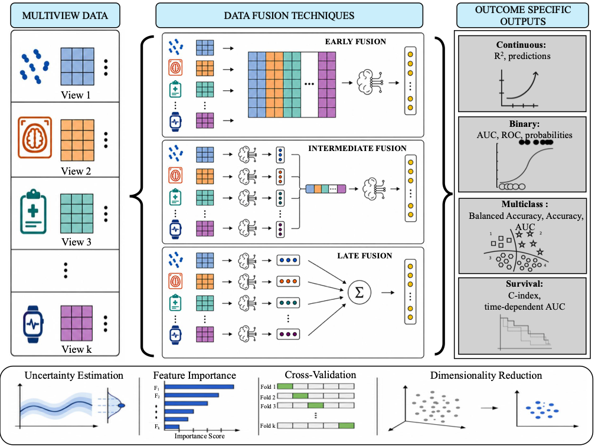

Figure: IntegratedLearner GitHub repository (MIT licence). The paper’s default is **late fusion** with BART base learners.

## The IntegratedLearner algorithm

For $K$ omics layers measured on the same samples:

1. **Adjust** each layer for confounders and batch effects (optional)
2. **Preprocess and filter** each layer (optional)
3. **Base learners**: fit a BART model per layer to predict the outcome (cross-validated)
4. **Meta-learner**: combine the out-of-sample layer predictions with non-negative weights

The final model is a **weighted average of per-layer tree ensembles**

- Layer weights are interpretable: which omics carry the signal?
- Each layer keeps its own scale, noise and normalization

## Base learner: Bayesian additive regression trees

A **sum of many small trees**, each a weak learner (Chipman, George, and McCulloch 2010):

$$y = \sum_{j=1}^{m} g(\mathbf{x}; T_j, M_j) + \epsilon,
\qquad \epsilon \sim N(0, \sigma^2)$$

- $T_j$: tree structure; $M_j$: terminal-node values
- Regularization priors keep each tree small, so no single tree dominates
- Binary outcomes via a probit link: $P(Y = 1 \mid \mathbf{x}) = \Phi\big(\sum_j g(\mathbf{x}; T_j, M_j)\big)$
- Fitted by **backfitting MCMC** → full posterior

What BART gives for free:

- Nonlinear effects and interactions **within** a layer
- Posterior samples → **credible and prediction intervals**
- **Variable inclusion proportions** as feature importance

## Meta-learner: combining the layers

Stack the $V$-fold out-of-sample predictions $\hat{y}_{ik}$ of each layer $k$ as “level 1” data.

**Continuous outcome**: non-negative least squares

$$\hat{\boldsymbol\alpha} = \arg\min_{\alpha_k \ge 0}\;
\sum_{i}\Big(y_i - \sum_{k=1}^{K}\alpha_k\,\hat{y}_{ik}\Big)^2$$

**Binary outcome**: minimize the rank loss $1 - \mathrm{AUC}$ of the combined score $\sum_k \alpha_k \hat{p}_{ik}$, with $\alpha_k \ge 0$

## Longitudinal biomarkers: two-stage model

Repeated omics measurements, cross-sectional outcome (e.g. IBD status)

**Stage 1**: per-feature linear mixed model

$$x_{ij} = \mathbf{w}_{ij}^T \boldsymbol\beta + \mathbf{z}_{ij}^T \mathbf{b}_i + \epsilon_{ij}$$

- Fixed effects $\boldsymbol\beta$: per-layer confounders
- Random effects $\mathbf{b}_i$ (here random intercepts): each subject’s own level

**Stage 2**: use the predicted random effects $\hat{\mathbf{b}}_i$ as features in IntegratedLearner

Keeps within-subject information that a cross-sectional model would discard.

## Other features

- **Missing layers in new data**: re-learn only the meta-learner weights on the available layers; the base learners are not refitted
- **Residualization** of confounders (e.g. age, antibiotics) before learning
- **Flexible learners**: any SuperLearner model as base or meta learner (random forest, elastic net, LASSO, …)
- **Early fusion** (concatenated model) fitted alongside for comparison

# Results

## Data sets

| Study | Subjects | Samples | Layers | Outcome |
| --- | --- | --- | --- | --- |
| PRISM (discovery) | 155 | 155 | metabolomics, microbiome | IBD vs. non-IBD |
| PRISM (validation) | 65 | 65 | metabolomics, microbiome | IBD vs. non-IBD |
| iHMP | 132 | 1785 | metabolomics, microbiome | IBD vs. non-IBD (longitudinal features) |
| Pregnancy (Ghaemi et al.) | 17 | 51 | 7 layers | gestational age |
| Labor onset (Stelzer et al.) | 53 + 8 | 150 + 21 | metabolome, proteome, immune | time to labor, gestational age |

Plus simulations from TCGA ovarian cancer multi-omics (InterSIM).

## IBD classification: PRISM

- Two layers: 8831 metabolites, 340 microbial species
- Features **residualized** for age and antibiotic use
- Compared with the concatenated random forest of Franzosa et al. (2019)

Findings:

- All classifiers clearly beat random: AUC 0.93–0.96 in 5-fold CV, 0.75–0.96 on the independent validation cohort
- **Species contributed more** to the fused prediction than metabolites, despite far fewer features: predictive power does not follow layer size
- IntegratedLearner **outperformed Franzosa et al. on external validation**, and also stacked elastic net and DIABLO
- Wide 95% credible intervals reflect a heterogeneous “non-IBD” group: a single point estimate would be misleading

## Gestational age: pregnancy multi-omics

- 7 layers, 17 women, 3 time points each; leave-one-subject-out CV
- Compared many base × meta learner combinations in one framework
- **BART + NNLS** was among the best methods
- Fused models beat every single-layer model, across algorithms
- Concatenation did not beat the ensemble
- Top layers by weight: microbiome, metabolomics, plasma SomaLogic

## Longitudinal biomarkers: iHMP

- Predict **IBD status per subject** from up to 24 time points of metagenomics and metabolomics
- Two-stage approach: random intercepts → BART → NNLS
- Best cross-validated AUC among the compared methods
- **Metabolomics** carried the largest weight
- Top features agree with the original univariate analysis: loss of obligate anaerobes and butyrate producers (e.g. *Roseburia hominis*), enrichment of bile-acid products
- Also finds sets of **weakly predictive features that are jointly strongly predictive**

## Missing layers: labor onset

- Training: metabolome, proteome and immune layers
- Validation cohort: **metabolomics missing**
- Re-learn only the layer weights on the layers available in both cohorts; base learners are reused
- Beat the LASSO stacking of the original study (Stelzer et al.) for both time to labor and gestational age
- **Proteomics** was the top contributor, before and after the update
- Existing methods would have to drop non-matching layers already during training

## Simulations

TCGA-like multi-omics (InterSIM): 131 genes, 367 methylation sites, 160 proteins; $n$ = 200, 500, 1000; SNR = 1, 5, 10; 100 replicates

| Scenario | IntegratedLearner vs. stacked linear models |
| --- | --- |
| Highly nonlinear (Friedman function) | **best in all 9 settings** (e.g. $R^2$ 0.81 vs. 0.63 at $n$ = 1000, SNR 10) |
| Highly linear | best in 5 of 9 settings |
| Fully linear | second best: regularized linear models win; always beats concatenated RF |

Runtime is on par with the frequentist methods, even though it combines MCMC with cross-validation, thanks to the fast *bartMachine* implementation of BART.

# In practice

## The R package today

The GitHub version extends the paper’s method:

- Input: **MultiAssayExperiment** (recommended) or legacy PCL lists
- Outcomes: continuous, binary, **multiclass**, **survival**
- Fusion: early (`run_concat`), late (`run_stacked`), and intermediate / cooperative learning (`run_intermediate`, via *multiview*)
- Fold-safe feature filtering and supervised screening
- Base learners: `sl_bart` (paper default, needs Java ≥ 21), any SuperLearner `SL.*` learner, and native multiclass and survival learners

```r
BiocManager::install("himelmallick/IntegratedLearner")
```

## Example 1: IBD classification (PRISM)

Train on PRISM, validate on an independent cohort (NLIBD)

```r
library(IntegratedLearner)
library(MultiAssayExperiment)

data("PRISM_MAE", package = "IntegratedLearner")   # training
data("NLIBD_MAE", package = "IntegratedLearner")   # validation

experiments(PRISM_MAE)
```

```
ExperimentList class object of length 2:
 [1] species: SummarizedExperiment with 340 rows and 155 columns
 [2] metabolites: SummarizedExperiment with 1500 rows and 155 columns
```

```r
table(IBD = colData(PRISM_MAE)$Y)
```

```
IBD
  0   1
 34 121
```

## Fit: BART per layer + NNLS/AUC meta-learner

```r
fit_bin <- IntegratedLearner(
  MAE_train = PRISM_MAE,
  MAE_valid = NLIBD_MAE,
  folds = 5,
  base_learner = "sl_bart",        # BART base learners (paper default)
  meta_learner = "sl_nnls_auc",    # non-negative weights, maximize AUC
  filter_method = "prevalence", filter_pct = 40,
  run_screening = TRUE, screen_pct = 30,
  print_learner = FALSE,
  family = binomial()
)
```

Also fits the **concatenated** model (early fusion) for comparison. Filtering and screening are fold-safe (learned only on training folds).

## Results: AUC and layer weights

```r
round(rbind(
  train = fit_bin$AUC.train,
  valid = fit_bin$AUC.test
), 2)
```

```
      metabolites species stacked concatenated
train        0.88    0.94    0.93         0.95
valid        0.72    0.71    0.71         0.84
```

```r
# Layer weights of the stacked model
fit_bin$weights
```

```
metabolites     species
          0           1
```

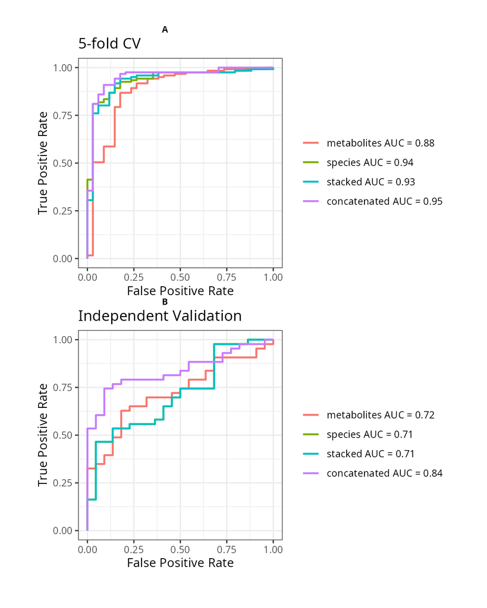

## What does this example show?

- In cross-validation all models reach AUC ≈ 0.9
- The meta-learner puts **nearly all weight on species**, echoing the paper: the smaller layer carries more signal
- On the **independent cohort** AUC drops for the single layers and the stacked model; in this run the concatenated model generalizes best
- With **random forests** (same settings) external AUC is similar or lower (stacked 0.64); weights shift to species 0.60, metabolites 0.40
- The packaged PRISM data are a reduced version (1500 metabolites) without the paper’s residualization of confounders; results also vary slightly between runs (MCMC)

Lesson: **always check external validation**, and compare the fusion strategies on your own data; IntegratedLearner makes that comparison easy.

## Example 2: gestational age (pregnancy)

7 omics layers, 17 women, repeated samples; continuous outcome

```r
data("pregnancy_MAE", package = "IntegratedLearner")

fit_cont <- IntegratedLearner(
  MAE_train = pregnancy_MAE,
  folds = 5,
  base_learner = "sl_bart",
  meta_learner = "sl_nnls_auc",
  filter_method = "variance", filter_pct = 40,
  run_screening = TRUE, screen_pct = 30,
  print_learner = FALSE,
  family = gaussian()
)
```

## Results: prediction accuracy and layer weights

```r
data.frame(
  R2     = round(fit_cont$R2.train, 2),
  weight = round(fit_cont$weights[names(fit_cont$R2.train)], 2)
)
```

```
                  R2 weight
CellfreeRNA     0.14   0.00
ImmuneSystem    0.01   0.00
Metabolomics    0.70   0.44
Microbiome      0.59   0.30
PlasmaLuminex   0.15   0.00
PlasmaSomalogic 0.65   0.27
SerumLuminex    0.00   0.00
stacked         0.80     NA
concatenated    0.42     NA
```

As in the paper, the stacked model beats every single layer, and metabolomics, microbiome and plasma SomaLogic get the largest weights.

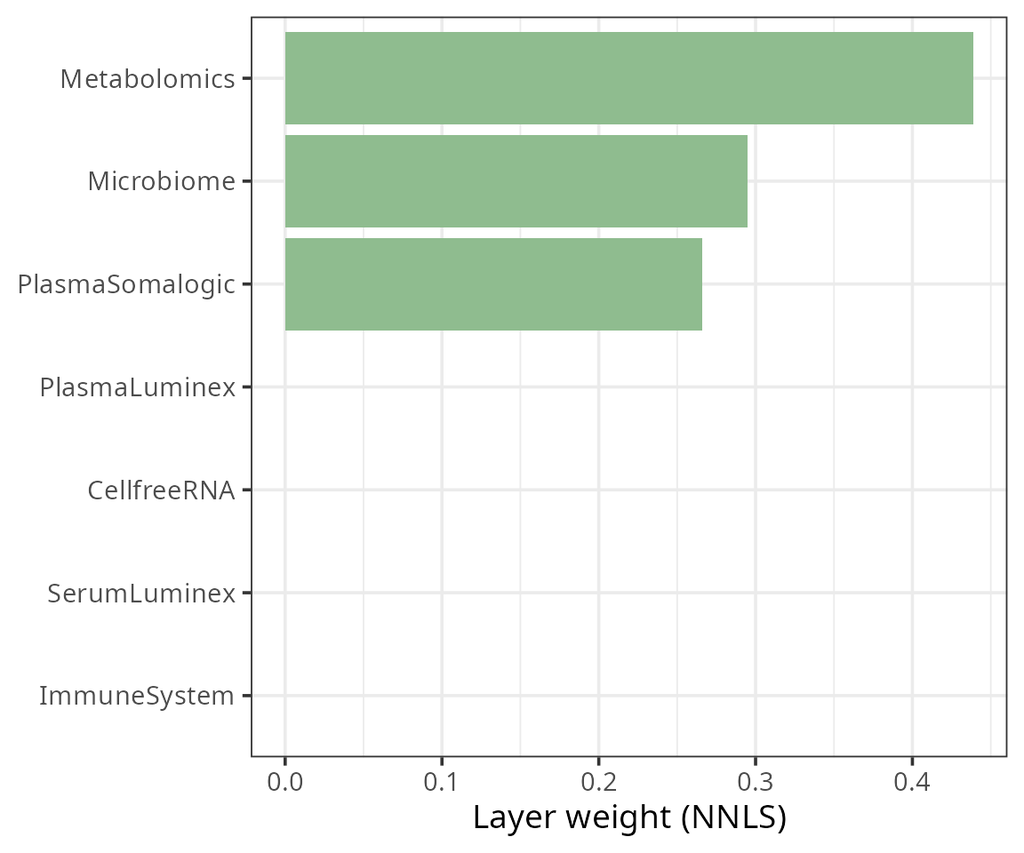

## Uncertainty: credible intervals

Weight the posterior draws of each layer’s BART model by the layer weights:

```r
post <- lapply(seq_along(fit_cont$weights), function(k) {
  m <- fit_cont$model_fits$model_layers[[k]]
  X <- fit_cont$X_train_layers[[k]][, m$training_data_features, drop = FALSE]
  bartMachine::bart_machine_get_posterior(m, X)$y_hat_posterior_samples
})
post_fused <- Reduce(`+`, Map(`*`, post, fit_cont$weights))  # samples x draws
dim(post_fused)
```

```
[1]   51 1000
```

## Uncertainty: credible intervals

```r
library(bayesplot)
rownames(post_fused) <- rownames(fit_cont$X_train_layers[[1]])
y   <- setNames(fit_cont$Y_train, rownames(post_fused))
ord <- names(sort(rowMeans(post_fused)))

mcmc_intervals(t(post_fused), prob = 0.68, prob_outer = 0.95) +
  scale_y_discrete(limits = ord) +
  geom_point(aes(x = y[ord], y = ord), shape = 1, size = 2) +
  coord_flip() +
  labs(x = "Gestational age", y = "Samples (fitted, training data)") +
  theme_bw(base_size = 14) +
  theme(axis.text.x = element_blank())
```

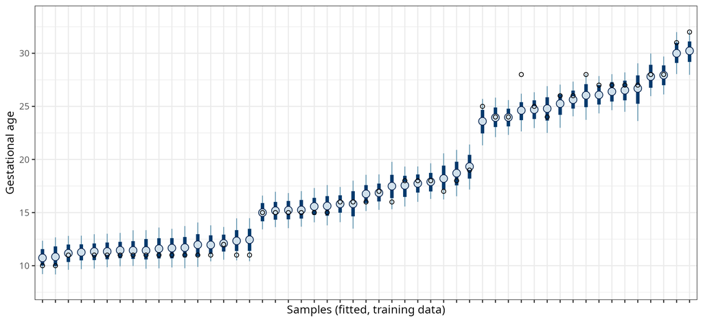

Thick (thin) bars: 68% (95%) credible intervals of the fused prediction; circles: observed values.

## Feature importance: BART inclusion proportions

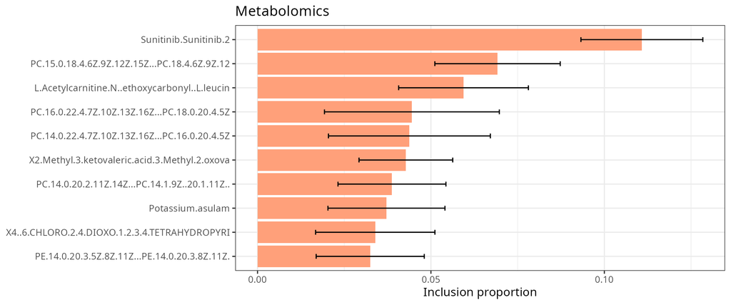

```r
top_layer <- names(which.max(fit_cont$weights))
invisible(capture.output(  # silence progress output
  vi <- bartMachine::investigate_var_importance(
    fit_cont$model_fits$model_layers[[top_layer]], plot = FALSE
  )
))
top <- head(sort(vi$avg_var_props, decreasing = TRUE), 10)
df  <- data.frame(feature = substr(names(top), 1, 45), prop = top,
                  sd = vi$sd_var_props[names(top)])

ggplot(df, aes(reorder(feature, prop), prop)) +
  geom_col(fill = "lightsalmon") +
  geom_errorbar(aes(ymin = pmax(prop - sd, 0), ymax = prop + sd), width = 0.2) +
  coord_flip() +
  labs(x = NULL, y = "Inclusion proportion", title = top_layer) +
  theme_bw(base_size = 14)
```

## Other options

```r
# Swap learners: any SuperLearner model as base / meta learner
IntegratedLearner(MAE_train = mae, base_learner = "SL.randomForest",
                  meta_learner = "sl_nnls_auc", family = binomial())

# Multiclass outcome (native multiclass backend)
IntegratedLearner(MAE_train = mae, outcome_col = "diseaseCat",
                  base_learner = "randomforest", meta_learner = "randomforest",
                  family = binomial())

# Survival outcome
IntegratedLearner(MAE_train = mae, base_learner = "surv.coxph")

# Intermediate fusion: cooperative learning (multiview)
IntegratedLearner(MAE_train = mae, run_intermediate = TRUE,
                  family = binomial())

# New data with missing layers: re-learn only the layer weights
update.learner(fit, feature_table_valid = ft, feature_metadata_valid = fm,
               sample_metadata_valid = sm)
```

## Limitations and open questions

- Base learners are fitted **per layer**: no information sharing between layers in the first stage
- BART captures interactions **within** a layer, not **across** layers
- The two-stage longitudinal model does not model **time** explicitly
- Only whole-layer missingness is handled, not missing features within a layer
- Weighted feature importance (layer weight × within-layer importance) can be dominated by one layer
- Prior knowledge (e.g. regulatory networks) is not yet used

## Take-home messages

- IntegratedLearner **fits one Bayesian model per omics layer** and **learns how much to trust each layer**
- Layer weights, feature inclusion proportions and credible intervals make the predictions **interpretable and uncertainty-aware**
- Handles **longitudinal biomarkers** and **missing layers** in new data
- Strongest when effects are **nonlinear**; with purely linear signal, regularized linear stacking can be better
- Runs directly on a **MultiAssayExperiment**

## References

Chipman, Hugh A., Edward I. George, and Robert E. McCulloch. 2010. “BART: Bayesian Additive Regression Trees.” *The Annals of Applied Statistics* 4 (1): 266–98. https://doi.org/10.1214/09-AOAS285.

Franzosa, Eric A., Alexandra Sirota-Madi, Julian Avila-Pacheco, Nadine Fornelos, Henry J. Haiser, Stefan Reinker, Tommi Vatanen, et al. 2019. “Gut Microbiome Structure and Metabolic Activity in Inflammatory Bowel Disease.” *Nature Microbiology* 4 (2): 293–305. https://doi.org/10.1038/s41564-018-0306-4.

Ghaemi, Mohammad Sajjad, Daniel B. DiGiulio, Kévin Contrepois, Benjamin Callahan, Thuy T. M. Ngo, et al. 2019. “Multiomics Modeling of the Immunome, Transcriptome, Microbiome, Proteome and Metabolome Adaptations During Human Pregnancy.” *Bioinformatics* 35 (1): 95–103. https://doi.org/10.1093/bioinformatics/bty537.

Mallick, Himel, Anupreet Porwal, Satabdi Saha, Piyali Basak, Vladimir Svetnik, and Erina Paul. 2024. “An Integrated Bayesian Framework for Multi-Omics Prediction and Classification.” *Statistics in Medicine* 43 (5): 983–1002. https://doi.org/10.1002/sim.9953.

Singh, Amrit, Casey P. Shannon, Benoı̂t Gautier, Florian Rohart, Michaël Vacher, Scott J. Tebbutt, and Kim-Anh Lê Cao. 2019. “DIABLO: An Integrative Approach for Identifying Key Molecular Drivers from Multi-Omics Assays.” *Bioinformatics* 35 (17): 3055–62. https://doi.org/10.1093/bioinformatics/bty1054.

Stelzer, Ina A., Mohammad S. Ghaemi, Xiaoyuan Han, Kazuo Ando, et al. 2021. “Integrated Trajectories of the Maternal Metabolome, Proteome, and Immunome Predict Labor Onset.” *Science Translational Medicine* 13 (592): eabd9898. https://doi.org/10.1126/scitranslmed.abd9898.

Software: https://github.com/himelmallick/IntegratedLearner. Workflow figure from the IntegratedLearner repository (MIT licence).